# BST270 Individual Project

Ziqi Fu

2025-01-25

## Dependencies

This notebook can be reproduced by installing the following R packages:

- ggplot2
- dplyr
- readr
- tidyr
- magrittr
- knitr

```r
library(ggplot2)
library(dplyr)
library(readr)
library(tidyr)
library(magrittr)
library(knitr)
```

For packages that are not installed, use the command `install.packages('PACKAGE_NAME')` for installation.

## 1. Reproducing the table in article [Where Are America’s Librarians?](https://fivethirtyeight.com/features/where-are-americas-librarians/)

We first download the data file `librarians-by-msa.csv` from its [GitHub repo](https://github.com/fivethirtyeight/data/tree/master/librarians). A copy of this data file has also been stored locally in the `Data` directory. Detailed codes are available in the end of this file.

| METROPOLITAN AREA | JOB QUOTIENT | NUMBER OF LIBRARIANS | LOWER ESTIMATE | UPPER ESTIMATE |
| --- | --- | --- | --- | --- |
| Owensboro, KY | 2.10 | 100 | 88 | 112 |
| Nassau-Suffolk, NY Metropolitan Division | 2.05 | 2530 | 2374 | 2686 |
| Bethesda-Rockville-Frederick, MD Metropolitan Division | 2.04 | 1140 | 1057 | 1223 |
| New Haven, CT | 2.01 | 550 | 503 | 597 |
| Haverhill-North Andover-Amesbury, MA-NH NECTA Division | 1.99 | 160 | 142 | 178 |
| Tallahassee, FL | 1.98 | 310 | 280 | 340 |
| Durham-Chapel Hill, NC | 1.96 | 540 | 494 | 586 |
| Ithaca, NY | 1.95 | 100 | 88 | 112 |
| Dover, DE | 1.95 | 120 | 106 | 134 |
| St. Joseph, MO-KS | 1.94 | 100 | 88 | 112 |

### Notes

The lower and upper estimates are computed using `SD=1`, and the original data does not contain information about `HAS A COLLEGE` for the selected areas. For simplicity, we will skip the last columns, since all the selected areas are indicated to have a college in the original table we try to replicate. All the numbers in this table match perfectly with the original table.

## 2. Reproducing the first graph in article [The Dallas Shooting Was Among The Deadliest For Police In U.S. History](https://fivethirtyeight.com/features/the-dallas-shooting-was-among-the-deadliest-for-police-in-u-s-history/)

We first download the cleaned version of the data `clean_data.csv` from its [GitHub repo](https://github.com/fivethirtyeight/data/tree/master/police-deaths). This data file has been renamed as `police-death-clean.csv` and stored under the `/Data` directory. We are reproducing the first graph in the original article, and the detailed codes are attached below.

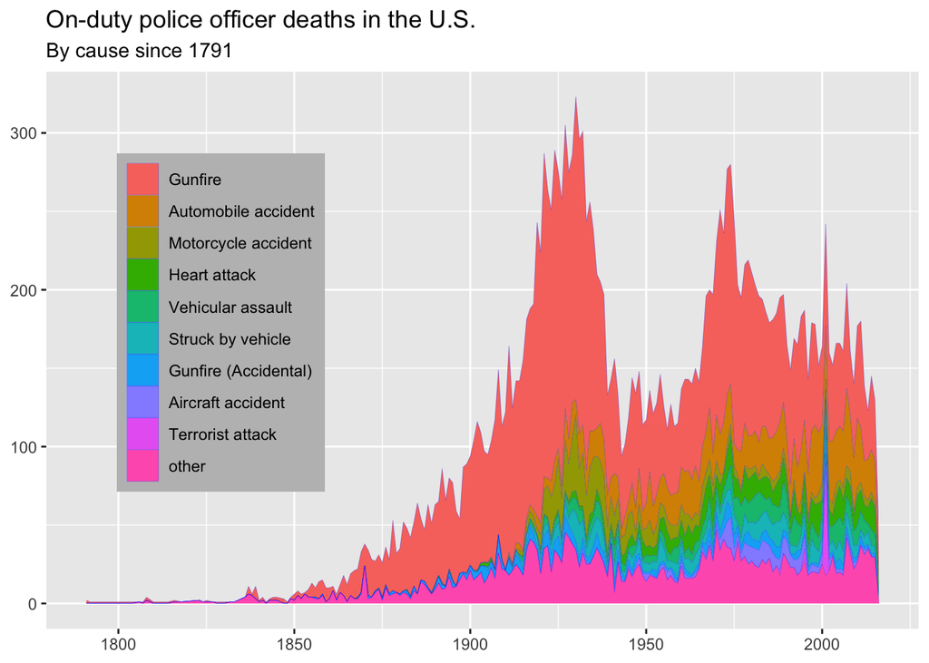

## Codes for reproducing table 1

```r
# Load and clean data
lib.data=read.csv("Data/librarians-by-msa.csv", header=T)
names(lib.data)=tolower(names(lib.data))
lib.data$tot_emp=as.numeric(gsub("[$]|,", "", lib.data$tot_emp))
lib.data$emp_prse=as.numeric(gsub("[$]|,", "", lib.data$emp_prse))
lib.data$jobs_1000=as.double(lib.data$jobs_1000) %>% round(2)
lib.data = drop_na(lib.data)

# Build model and get coefficients
nl.model=nls(data=lib.data, formula=emp_prse~a*tot_emp^b, start=list(a=1, b=1))
a=coef(nl.model)[1]
b=coef(nl.model)[2]

# Get lower and upper estimates
lib.data$mor=(a*(lib.data$tot_emp^b))*1 #SD=1
lib.data$HE=(lib.data$tot_emp*(1+(lib.data$mor/100))) %>% round(0)
lib.data$LE=(lib.data$tot_emp*(1-(lib.data$mor/100))) %>% round(0)

# select areas to generate a table
select.area = c('Owensboro, KY',
                 'Nassau-Suffolk, NY Metropolitan Division',
                 'Bethesda-Rockville-Frederick, MD Metropolitan Division',
                 'New Haven, CT',
                 'Haverhill-North Andover-Amesbury, MA-NH NECTA Division',
                 'Tallahassee, FL',
                 'Durham-Chapel Hill, NC',
                 'Ithaca, NY',
                 'Dover, DE',
                 'St. Joseph, MO-KS')

tb = lib.data[match(select.area,lib.data$area_name),c(2,5,3,9,8)] %>% as.data.frame()
colnames(tb) = c('METROPOLITAN AREA','JOB QUOTIENT','NUMBER OF LIBRARIANS','LOWER ESTIMATE','UPPER ESTIMATE')
kable(tb,row.names = F) # display the table
```

## Codes for reproducing graph 1

```r
# Load and clean data
clean_data = read.csv('Data/police-death-clean.csv') %>% filter(canine == FALSE)

# Major categories found in the data
large_categories = clean_data %>%
      group_by(year, cause_short) %>%
      summarize(count = n()) %>%
      data.frame() %>%
      filter(count >= 20) %>% # chose the category if # incidence >= 20
      select(cause_short) %>%
      unique()
cat_to_plot = c(large_categories$cause_short, "Gunfire (Accidental)") #also include accidental gunfire cases

plot_order = clean_data %>%
    mutate(cat = ifelse(cause_short %in% cat_to_plot, cause_short, 'other')) %>%
    group_by(cat) %>%
    summarize(count = n()) %>%
    data.frame() %>%
    arrange(desc(count)) %>%
    extract2(1)

# Move order to the end
plot_order = c(plot_order[! (plot_order == 'other')], 'other')

# Create data for plotting
data_for_plot = clean_data %>%
      mutate(cat = ifelse(cause_short %in% cat_to_plot, cause_short, 'other')) %>%
      group_by(year, cat) %>%
      summarize(count = n()) %>%
      data.frame() %>%
      spread(cat, count)
data_for_plot[is.na(data_for_plot)] = 0
data_for_plot = data_for_plot %>%
      gather(cat, count, -year) %>%
      mutate(cat = factor(cat, levels=plot_order)) %>%
      arrange(cat)

# generate the plot
ggplot(data_for_plot, aes(x=year, y=count, group=cat, order=cat)) +
      geom_area(aes(fill=cat),color='blue',size=0.05, position='stack') +
      labs(fill=NULL,title='On-duty police officer deaths in the U.S.',subtitle='By cause since 1791',x=NULL,y=NULL)+
      theme(legend.position = c(0.2,0.55),legend.background = element_rect(fill = "grey"))
```